# COM747 Week 3: Probability Distributions and EDA

Lecturer demonstration notebook

# Today’s question

> A student scores **70**. Is that a good mark?

> You cannot answer without knowing the **distribution**: where the marks are centred, how spread out they are, and what shape they make. Today we describe distributions and use them to calculate **probabilities**.

**Learning outcomes**

1. Distinguish discrete and continuous random variables and their distributions.
2. Draw and interpret histograms, density plots and box plots.
3. Calculate normal probabilities with `pnorm()` and `qnorm()`.
4. Describe shape (skewness, kurtosis) and standardise data with z-scores.
5. Explain the central limit theorem and test for normality.

```r
# A helper used all session: draw a normal curve and shade a region (like tigerstats::pnormGC)
shade_normal <- function(lo = -Inf, hi = Inf, mean = 0, sd = 1, main = NULL) {
  x <- seq(mean - 4 * sd, mean + 4 * sd, length.out = 400)
  y <- dnorm(x, mean, sd)
  p <- pnorm(hi, mean, sd) - pnorm(lo, mean, sd)
  if (is.null(main)) main <- sprintf("P(%s < X < %s) = %.4f", lo, hi, p)
  plot(x, y, type = "l", lwd = 2, col = "#2b5fa6", xlab = "x", ylab = "density", main = main)
  xs <- x[x >= max(lo, min(x)) & x <= min(hi, max(x))]
  polygon(c(xs[1], xs, xs[length(xs)]), c(0, dnorm(xs, mean, sd), 0),
          col = adjustcolor("#2b5fa6", 0.35), border = NA)
  abline(v = mean, lty = 3)
  invisible(p)
}
```

# Part 1: Random variables and discrete distributions

> A **random variable** X takes numerical values from a random process. **Discrete**: countable (students in a class, heads in coin flips). **Continuous**: measured (time to run a mile, height).

### Two coin flips: how many heads?

Outcomes: HH, HT, TH, TT.

**PREDICT** What is P(X = 1)? What is P(X ≤ 1)?

```r
heads <- 0:2
prob  <- dbinom(heads, size = 2, prob = 0.5)
prob
```

```
## [1] 0.25 0.50 0.25
```

```r
pbinom(1, size = 2, prob = 0.5)      # cumulative: P(X <= 1) = 0.25 + 0.50
```

```
## [1] 0.75
```

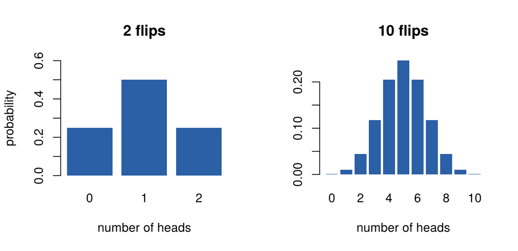

```r
par(mfrow = c(1, 2))
barplot(prob, names.arg = heads, col = "#2b5fa6", border = NA, ylim = c(0, 0.6),
        main = "2 flips", xlab = "number of heads", ylab = "probability")
barplot(dbinom(0:10, 10, 0.5), names.arg = 0:10, col = "#2b5fa6", border = NA,
        main = "10 flips", xlab = "number of heads")
```

```r
par(mfrow = c(1, 1))
```

### Check it by simulation

```r
set.seed(1)
flips <- replicate(10000, sum(sample(c(0, 1), 2, replace = TRUE)))
table(flips) / 10000        # close to 0.25, 0.50, 0.25
```

```
## flips
##      0      1      2
## 0.2584 0.4936 0.2480
```

# Part 2: Continuous variables and histograms

> For continuous data we group values into **bins** and count. The picture depends on how many bins you choose.

```r
rundata <- read.csv("rundata.csv")
summary(rundata$FirstRun)
```

```
##    Min. 1st Qu.  Median    Mean 3rd Qu.    Max.
##    2.64   23.54   29.24   28.74   34.21   56.14
```

```r
nclass.Sturges(rundata$FirstRun)    # Sturges' rule: about log2(n) + 1 bins
```

```
## [1] 8
```

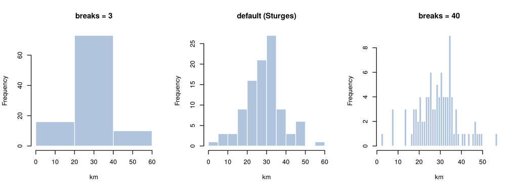

```r
par(mfrow = c(1, 3))
hist(rundata$FirstRun, breaks = 3,  col = "lightsteelblue", border = "white", main = "breaks = 3",  xlab = "km")
hist(rundata$FirstRun,              col = "lightsteelblue", border = "white", main = "default (Sturges)", xlab = "km")
hist(rundata$FirstRun, breaks = 40, col = "lightsteelblue", border = "white", main = "breaks = 40", xlab = "km")
```

```r
par(mfrow = c(1, 1))
```

**Ask:** Which histogram tells the most honest story? Too few bins hide the shape; too many show noise.

### Density: a smooth histogram

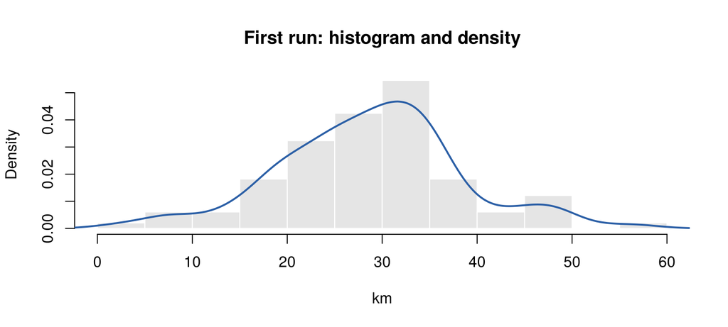

```r
hist(rundata$FirstRun, freq = FALSE, col = "grey90", border = "white",
     main = "First run: histogram and density", xlab = "km")
lines(density(rundata$FirstRun), lwd = 2, col = "#2b5fa6")
```

```r
# area under the density curve between 20 and 25 km = probability
dens_fun <- with(density(rundata$FirstRun), splinefun(x, y))
integrate(dens_fun, lower = 20, upper = 25)
```

```
## 0.1605854 with absolute error < 2.3e-06
```

```r
mean(rundata$FirstRun > 20 & rundata$FirstRun < 25)   # proportion in the data
```

```
## [1] 0.1616162
```

# Part 3: The normal distribution

> For a continuous variable, P(X = exactly 50) is **0**. We can only ask about **ranges**: the **area under the curve**.

Driving time to work: mean 50 minutes, SD 20.

**PREDICT** Is P(49 < X < 51) closer to 0.04, 0.4, or 0.9?

```r
pnorm(51, mean = 50, sd = 20) - pnorm(49, mean = 50, sd = 20)
```

```
## [1] 0.03987761
```

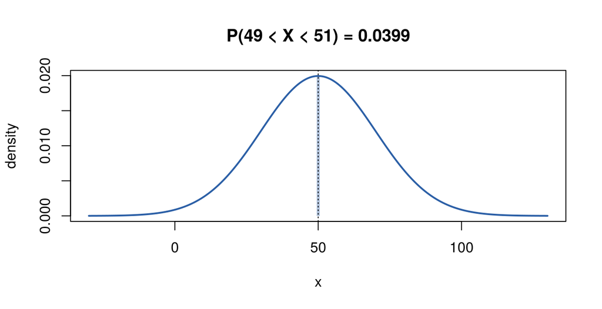

```r
shade_normal(49, 51, mean = 50, sd = 20)
```

```r
# The same with tigerstats (install.packages("tigerstats") first)
library(tigerstats)
pnormGC(c(49, 51), region = "between", mean = 50, sd = 20, graph = TRUE)
```

### The cumulative distribution function: `pnorm()`

`pnorm(q, mean, sd)` gives P(X ≤ q), the area to the **left** of q.

```r
pnorm(30, mean = 50, sd = 25)       # 0.2119
```

```
## [1] 0.2118554
```

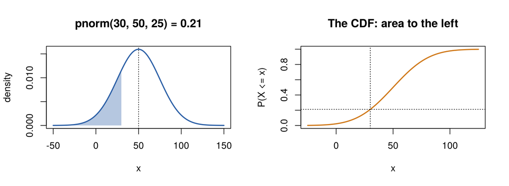

```r
par(mfrow = c(1, 2))
shade_normal(-Inf, 30, 50, 25, main = "pnorm(30, 50, 25) = 0.21")
x <- seq(-25, 125, length.out = 300)
plot(x, pnorm(x, 50, 25), type = "l", lwd = 2, col = "#d0791a",
     main = "The CDF: area to the left", ylab = "P(X <= x)")
abline(v = 30, h = pnorm(30, 50, 25), lty = 3)
```

```r
par(mfrow = c(1, 1))
```

### Exam marks: mean 55, SD 30

```r
pnorm(70, 55, 30) - pnorm(40, 55, 30)   # P(40 < X < 70)
```

```
## [1] 0.3829249
```

```r
1 - pnorm(70, 55, 30)                   # P(X > 70): above
```

```
## [1] 0.3085375
```

```r
pnorm(40, 55, 30)                       # P(X < 40): fail
```

```
## [1] 0.3085375
```

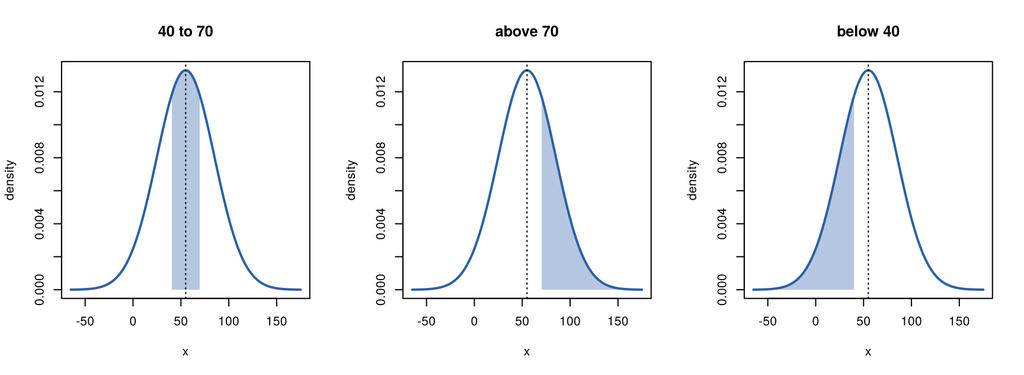

```r
par(mfrow = c(1, 3))
shade_normal(40, 70, 55, 30, main = "40 to 70")
shade_normal(70, Inf, 55, 30, main = "above 70")
shade_normal(-Inf, 40, 55, 30, main = "below 40")
```

```r
par(mfrow = c(1, 1))
```

### The other direction: `qnorm()`

*Marks have mean 55 and SD 15. What mark puts a student in the top 10%?*

```r
qnorm(0.90, mean = 55, sd = 15)     # 74.2
```

```
## [1] 74.22327
```

### The empirical rule (68–95–99.7)

```r
pnorm(1) - pnorm(-1)
```

```
## [1] 0.6826895
```

```r
pnorm(2) - pnorm(-2)
```

```
## [1] 0.9544997
```

```r
pnorm(3) - pnorm(-3)
```

```
## [1] 0.9973002
```

```r
qnorm(0.975)        # 1.96: used for 95% confidence intervals next week
```

```
## [1] 1.959964
```

### Using real data: running speeds

```r
speed <- c(20, 24, 27, 28, 29, 30, 32, 33, 34, 36, 38, 39, 40, 40)
m <- mean(speed); s <- sd(speed)
c(mean = m, sd = s)
```

```
##      mean        sd
## 32.142857  6.175101
```

```r
pnorm(33, m, s) - pnorm(29, m, s)        # P(29 < X < 33)
```

```
## [1] 0.249807
```

```r
1 - (pnorm(33, m, s) - pnorm(29, m, s))  # outside 29 to 33
```

```
## [1] 0.750193
```

```r
pnorm(30, m, s)                          # P(X < 30)
```

```
## [1] 0.3642897
```

```r
1 - pnorm(30, m, s)                      # P(X > 30)
```

```
## [1] 0.6357103
```

**→ STUDENTS:** open the Week 3 page, use the normal probability explorer, then do the Core tasks.

# Part 4: Shape: skewness and kurtosis

| Measure | Normal value | Meaning |
| --- | --- | --- |
| Skewness | 0 | symmetry: positive = long right tail |
| Kurtosis | 3 | tails: > 3 heavy (leptokurtic), < 3 light (platykurtic) |

```r
skewness <- function(x) { m <- mean(x); n <- length(x); (sum((x - m)^3) / n) / (sum((x - m)^2) / n)^1.5 }
kurtosis <- function(x) { m <- mean(x); n <- length(x); (sum((x - m)^4) / n) / (sum((x - m)^2) / n)^2 }
# the 'moments' package gives the same: install.packages("moments"); moments::skewness(x)

time <- c(19.09, 19.55, 17.89, 17.73, 25.15, 27.27, 25.24, 21.05, 21.65, 20.92, 22.61, 15.71, 22.04, 22.60, 24.25)
skewness(time); kurtosis(time)          # about 0 and 2.3: symmetric, light tails
```

```
## [1] -0.01565162
```

```
## [1] 2.301051
```

```r
skewness(rundata$FirstRun); kurtosis(rundata$FirstRun)
```

```
## [1] 0.02439148
```

```
## [1] 3.529171
```

### A skewed variable: salaries

```r
set.seed(10)
salary <- round(rlnorm(1000, meanlog = log(30000), sdlog = 0.5))
c(mean = mean(salary), median = median(salary), skew = skewness(salary))
```

```
##         mean       median         skew
## 34103.180000 29955.000000     1.787751
```

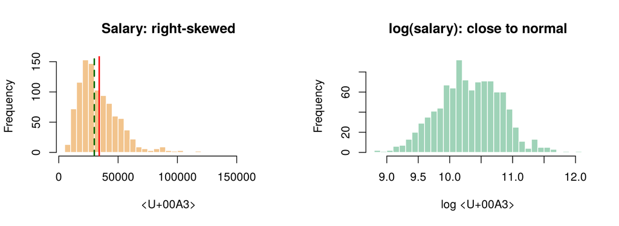

```r
par(mfrow = c(1, 2))
hist(salary, breaks = 40, col = "#f2c48d", border = "white", main = "Salary: right-skewed", xlab = "£")
abline(v = mean(salary), col = "red", lwd = 2); abline(v = median(salary), col = "darkgreen", lwd = 2, lty = 2)
hist(log(salary), breaks = 40, col = "#9fd3b8", border = "white", main = "log(salary): close to normal", xlab = "log £")
```

```r
par(mfrow = c(1, 1))
skewness(log(salary))
```

```
## [1] -0.008942981
```

> In a right-skewed variable the mean is pulled above the median. Report **median ± IQR** (non-parametric) rather than **mean ± SD** (parametric).

# Part 5: Standardisation and z-scores

$$z = \frac{x -
\text{mean}}{\text{sd}}$$

> A z-score says how many SDs a value is from the mean. It is **metric agnostic**: scores on different scales become comparable.

```r
set.seed(1)
weight <- round(rnorm(50, mean = 90, sd = 10))
summary(weight)
```

```
##    Min. 1st Qu.  Median    Mean 3rd Qu.    Max.
##   68.00   86.25   91.50   91.00   97.00  106.00
```

```r
(84 - mean(weight)) / sd(weight)        # z-score of 84 kg
```

```
## [1] -0.8398492
```

```r
(99 - mean(weight)) / sd(weight)
```

```
## [1] 0.9598276
```

```r
z <- as.numeric(scale(weight))          # every value at once
round(c(mean = mean(z), sd = sd(z)), 4) # always 0 and 1
```

```
## mean   sd
##    0    1
```

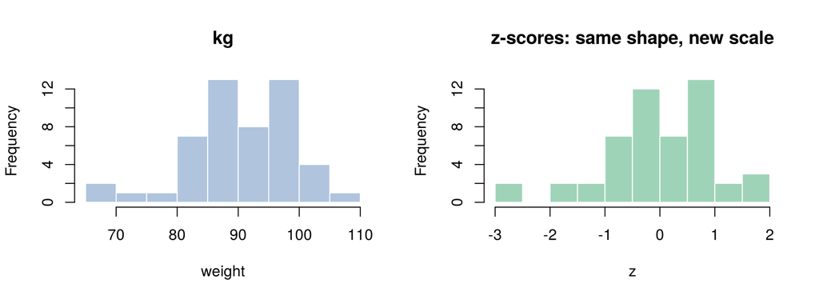

```r
par(mfrow = c(1, 2))
hist(weight, col = "lightsteelblue", border = "white", main = "kg")
hist(z, col = "#9fd3b8", border = "white", main = "z-scores: same shape, new scale")
```

```r
par(mfrow = c(1, 1))
```

### Why it matters: combining two tests on different scales

```r
quiz  <- c(2, 5, 3, 6, 7, 10, 15, 8, 9, 4)          # out of 15
exam  <- c(40, 55, 70, 80, 90, 94, 97, 88, 80, 90)  # out of 100
composite <- as.numeric(scale(quiz)) + as.numeric(scale(exam))
round(composite, 2)
```

```
##  [1] -3.36 -1.77 -1.47 -0.15  0.66  1.65  3.12  0.81  0.63 -0.12
```

```r
which.max(composite)     # best overall student, each test weighted equally
```

```
## [1] 7
```

### Positive-only scales

```r
z_84 <- (84 - mean(weight)) / sd(weight)
c(sigma = 16 * z_84 + 50, hull = 14 * z_84 + 50, t_scale = 10 * z_84 + 50)
```

```
##    sigma     hull  t_scale
## 36.56241 38.24211 41.60151
```

### Min–max normalisation (0 to 1): used a lot in machine learning

```r
normalise <- function(x) (x - min(x)) / (max(x) - min(x))
range(normalise(weight))
```

```
## [1] 0 1
```

```r
head(round(normalise(weight), 3))
```

```
## [1] 0.421 0.632 0.368 1.000 0.658 0.368
```

# Part 6: Is my variable normal?

> Shapiro–Wilk test. H0: the data are normally distributed. If p < 0.05, reject H0.

```r
shapiro.test(rundata$FirstRun)   # p = 0.37: no evidence against normality
```

```
##
##  Shapiro-Wilk normality test
##
## data:  rundata$FirstRun
## W = 0.98583, p-value = 0.371
```

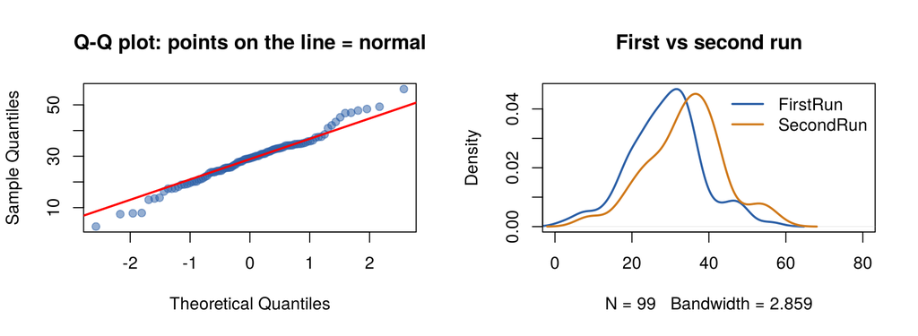

```r
par(mfrow = c(1, 2))
qqnorm(rundata$FirstRun, pch = 19, col = "#2b5fa680", main = "Q-Q plot: points on the line = normal")
qqline(rundata$FirstRun, col = "red", lwd = 2)
plot(density(rundata$FirstRun), col = "#2b5fa6", lwd = 2, xlim = c(0, 80),
     main = "First vs second run")
lines(density(rundata$SecondRun), col = "#d0791a", lwd = 2)
legend("topright", c("FirstRun", "SecondRun"), col = c("#2b5fa6", "#d0791a"), lwd = 2, bty = "n")
```

```r
par(mfrow = c(1, 1))
```

# Part 7: The central limit theorem

> Take many samples of size n and calculate each sample’s mean. If n is large (n ≥ 30), the **sample means** are approximately normal, **even when the population is not**.

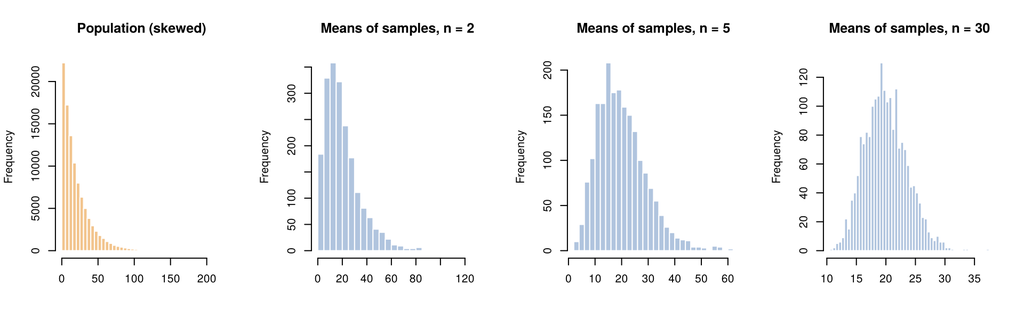

```r
set.seed(2)
population <- rexp(100000, rate = 1 / 20)      # strongly right-skewed
par(mfrow = c(1, 4))
hist(population, breaks = 50, col = "#f2c48d", border = "white", main = "Population (skewed)", xlab = "")
for (n in c(2, 5, 30)) {
  means <- replicate(2000, mean(sample(population, n)))
  hist(means, breaks = 40, col = "lightsteelblue", border = "white",
       main = paste("Means of samples, n =", n), xlab = "")
}
```

```r
par(mfrow = c(1, 1))
```

**Ask:** What happens to the **width** of the histogram of means as n grows? (It shrinks: next week this becomes the **standard error**.)

# Part 8: EDA on a real dataset

`student_data.csv`: 395 secondary-school students (UCI Student Performance). G1, G2, G3 are the period grades out of 20.

```r
students <- read.csv("student_data.csv")
dim(students)
```

```
## [1] 395  33
```

```r
names(students)
```

```
##  [1] "school"     "sex"        "age"        "address"    "famsize"
##  [6] "Pstatus"    "Medu"       "Fedu"       "Mjob"       "Fjob"
## [11] "reason"     "guardian"   "traveltime" "studytime"  "failures"
## [16] "schoolsup"  "famsup"     "paid"       "activities" "nursery"
## [21] "higher"     "internet"   "romantic"   "famrel"     "freetime"
## [26] "goout"      "Dalc"       "Walc"       "health"     "absences"
## [31] "G1"         "G2"         "G3"
```

```r
summary(students$G3)
```

```
##    Min. 1st Qu.  Median    Mean 3rd Qu.    Max.
##    0.00    8.00   11.00   10.42   14.00   20.00
```

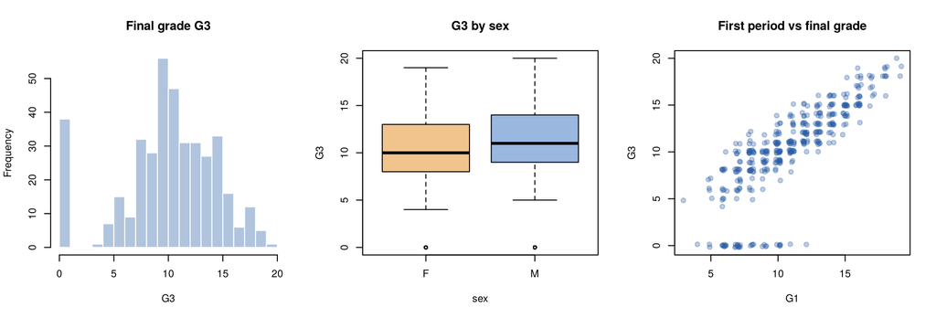

```r
par(mfrow = c(1, 3))
hist(students$G3, breaks = 0:20, col = "lightsteelblue", border = "white", main = "Final grade G3", xlab = "G3")
boxplot(G3 ~ sex, data = students, col = c("#f2c48d", "#9ab7e0"), main = "G3 by sex")
plot(jitter(students$G1), jitter(students$G3), pch = 19, col = "#2b5fa650",
     xlab = "G1", ylab = "G3", main = "First period vs final grade")
```

```r
par(mfrow = c(1, 1))

sum(students$G3 == 0)                         # 38 zeros: what might these mean?
```

```
## [1] 38
```

```r
skewness(students$G3)
```

```
## [1] -0.7298871
```

```r
shapiro.test(students$G3)
```

```
##
##  Shapiro-Wilk normality test
##
## data:  students$G3
## W = 0.92873, p-value = 8.836e-13
```

```r
tapply(students$G3, students$sex, mean)
```

```
##         F         M
##  9.966346 10.914439
```

```r
tapply(students$G3, students$internet, median)
```

```
##  no yes
##  10  11
```

```r
cor(students$G1, students$G3)
```

```
## [1] 0.8014679
```

**Ask:** 38 students have G3 = 0 but most had a G1 above 0. Are they real zeros or students who left? How would that change your analysis? (Data understanding → data preparation in CRISP-DM.)

### Discretisation: numbers into categories

```r
students$band <- cut(students$G3, breaks = c(-1, 9, 13, 20), labels = c("Fail", "Pass", "Good"))
table(students$band)
```

```
##
## Fail Pass Good
##  130  165  100
```

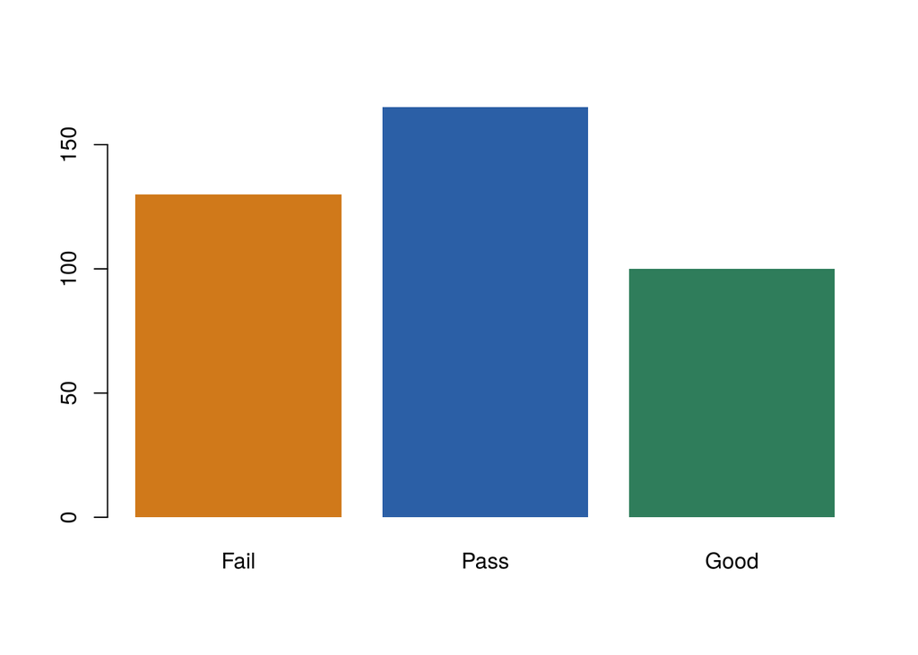

```r
barplot(table(students$band), col = c("#d0791a", "#2b5fa6", "#2f7d5b"), border = NA)
```

```r
# Entropy of a group (lower = purer). Used to choose good cut-points, e.g. in decision trees.
entropy <- function(counts) { p <- counts / sum(counts); -sum(p * log2(p)) }
entropy(c(30, 2))     # aged < 30: 30 earn < 60k, 2 earn > 60k  -> 0.337 (pure)
```

```
## [1] 0.3372901
```

```r
entropy(c(8, 22))     # aged > 30                               -> 0.837 (mixed)
```

```
## [1] 0.8366407
```

# Summary

| Question | R |
| --- | --- |
| Discrete probabilities | `dbinom()`, `pbinom()` |
| Shape of continuous data | `hist(breaks =)`, `density()`, `boxplot()`, `qqnorm()` |
| P(X ≤ q) for a normal | `pnorm(q, mean, sd)` |
| Value for a probability | `qnorm(p, mean, sd)` |
| Standardise | `scale()`, `(x - mean) / sd` |
| Normal? | `shapiro.test()` |
| Skew / tails | skewness (0), kurtosis (3) |

**Next week:** from samples to populations: standard error, confidence intervals and hypothesis tests.